# Global Music Trends

## Goal

Exploration of musical trends by year to year, differing by countries through employing statistical analysis of variables like genre, beats per minutes, length of songs, etc in order to generate conclusions on how music as a whole has transgressed and its potential trajectory going forth.

## Datasets

Utilizing two datasets from Kaggle. Firstly - *top10s.csv* which includes the top songs from the 2010-2019 in the world by Spotify and Billboards. 13 variables are explored and original intent was to make inferences based upon genre, mean of minutes per songs, and yearly trends. Second - *top50contry.csv* which includes the top 50 Spotify songs by each country from 1942-2019. 13 variables are explored as well, and original intent was the same as the prior dataset.

**Link to datasets**:

[Top10s.csv](https://www.kaggle.com/leonardopena/top-spotify-songs-from-20102019-by-year)

[Top50contry.csv](https://www.kaggle.com/leonardopena/top-50-spotify-songs-by-each-country)

## Motivation

Music has been apart of humanity since the beginning of our creation. It plays a important role in countless lives for various reasons - whether for personal uses like: reducing stress, improving mood to more formal uses like: work songs, military marches, etc., the uses for music are countless. Due to its importance and prevalence in daily life globally - it’s important to understand the trends as humanity has progressed and be able to generate meaningful conclusions based on upon various factors that have influenced its transgression over the years.

**Hope you enjoy!**

## Basic Overview

| Top Genres | Song Count |
| --- | --- |
| adult standards | 145 |
| latin | 113 |
| dance pop | 76 |
| pop | 41 |
| album rock | 30 |
| desi pop | 30 |
| french hip hop | 22 |
| canadian pop | 21 |
| j-pop | 21 |

For clarity:

**Pop Music** - Also known as popular music can be classified as a genre which appeals to the taste of a large segment of a given population.

**Adult Standards** - Musical genre aimed at “mature” adults - those above the ages of 50 comprised of various genres.

**Desi Pop/J-Pop** - Cultural specific pop music; Desi is for the country of India and J is for the country of Japan.

##### Global - Pre & Post 2000 Top Genres

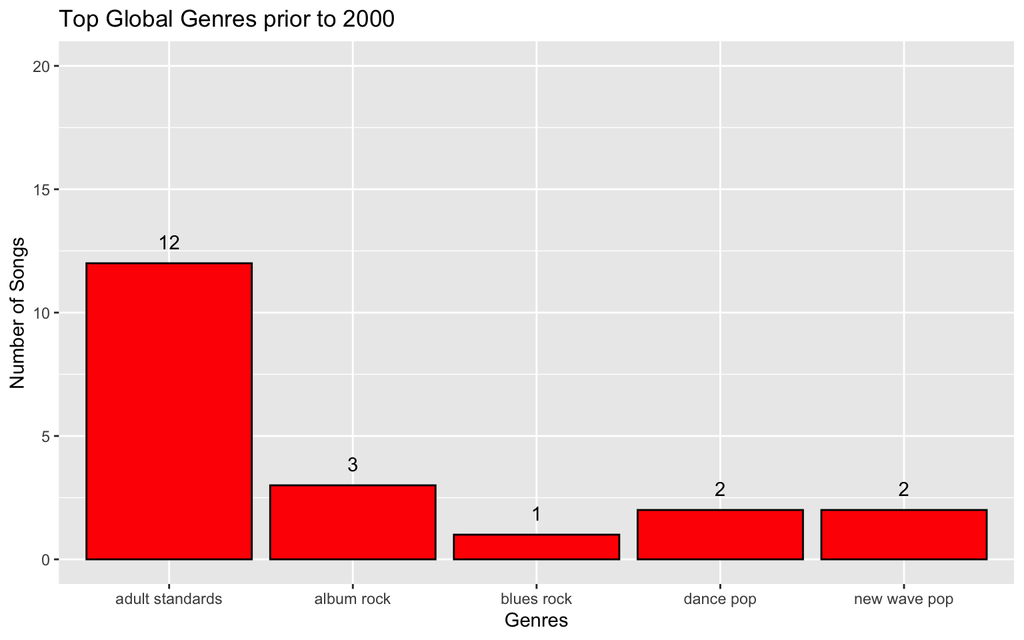

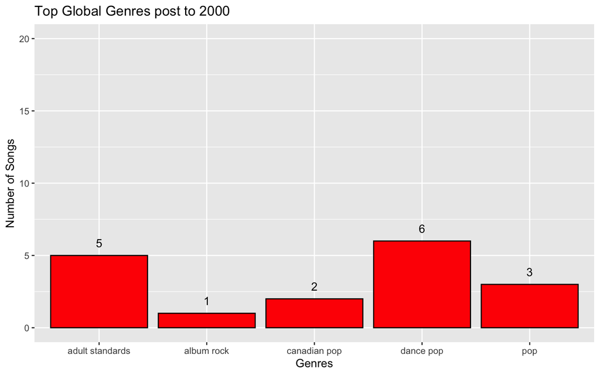

This is a illustration showing the progression of musical genres globally. Although some genres withstood the test of time (adult standard & dance pop), you can see how genres begins to diversify by not only introducing new ones, but modifying others as well. 2000 was chosen as the cut-off point because it was the peak of the CD era - which began the transition of music listening through other platforms & mediums.

## Shiny Application

##### Interactive app to generate relationships between variables

[interactive chart not shown]

Includes two visualization - histogram and scatterplot.

Variables included:

**Beats Per Minute** (bpm) - The tempo of the song

**Energy** (nrgy) - The energy of a song - the higher the value, the more energtic song

**Danceability** (dnce) - The higher the value, the easier it is to dance to this song

**Loudness** (dB) - The higher the value, the louder the song

**Liveness** (live) - The higher the value, the more likely the song is a live recording

**Valence** (val) - The higher the value, the more positive mood for the song

**Duration** (dur) - The duration of the song

**Acousticness** (acous) - The higher the value the more acoustic the song is

**Speechiness** (spch) - The higher the value the more spoken word the song contains

**Popularity** (pop) - The higher the value the more popular the song is

Variable names and descriptions were created by Spotify - recorded measurements by listeners who reported. You can look and contribute at: [Organize Your Music](http://organizeyourmusic.playlistmachinery.com)

## Map

##### Global map highlighting countries danceability between years 1942-2019

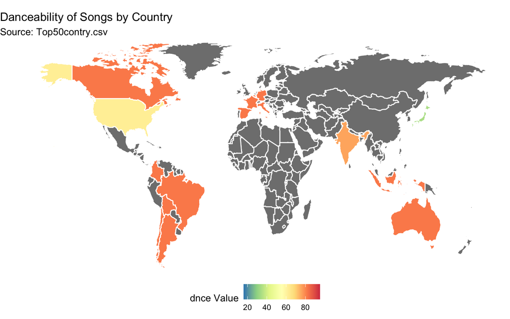

## Music Over The Years - Videos

- [Decade of Pop - Top 100 mashup](https://www.youtube.com/watch?v=UhIte8t6BEg)
- [40 Years of Rap](https://www.youtube.com/watch?v=0AJm9XhidiM)
- [20 Years - Top 200 songs](https://www.youtube.com/watch?v=mccohr-fkws)

## Conclusions

Through working on this PUG project - useful insights were able to be concluded based upon the datasets utilized and statistical analysis. Quick summary of some interesting findings -

**1)** If you’re looking to dance, South America is the place to be, in particular: Chile, Argentina, and Bolivia

**2)** Travel with earplugs if you will be listening to music in India, Australia, or Argentina

**3)** In the mood for good and positive vibes? Argentina, Columbia, and Australia should be your destination of choice.

## Limitations

Between both datasets used, data for earlier years (prior to 1970) was sparse which limited the meaningful conclusion able to be generated between years and time periods. Additionally, some smaller countries did not have any data available and data for those which did was limited at times. To combat this and strengthen analysis - looking for a more holistic dataset or adding on to the current dataset(s) with increased observations from earlier dates and smaller countries would help.